# 实体对齐文献阅读笔记

- 映射基数：可能是1-1或1-n，对于前向邻居$E$，如果是$|E|==1$，则是1-1，否则1-n，n=$|E|$。映射基数不同，每个节点重要性也不同。所以基于映射基数的权重设置为

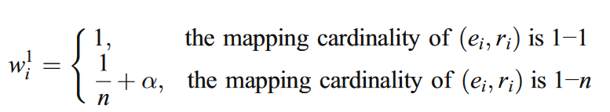

- 关系关联度：包括$r_i$和其它邻居中关系的关联度。关系的关联度如下表示：

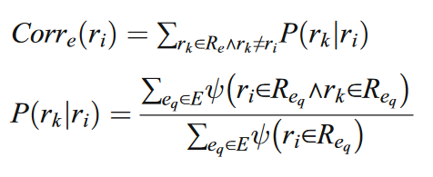

  ，$\psi(x)=1,x=true$，否则为0；两个KG之间的关系也有关联度，

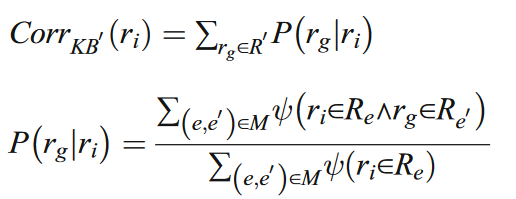

  。基于以上两个关联度，总关联度为

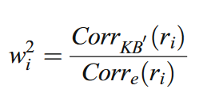

  。关系的本KG关联度越高，说明本身的独特性越低，可以被其它关系取代；但是KG'关联度高，说明可以帮助嵌入
- 注意力机制：以上两种权重方法没有考虑到向量表示中的信息，

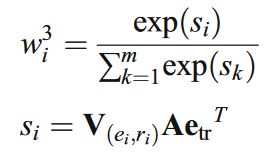

  ，最终权重，

邻居嵌入

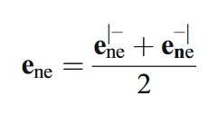

邻居嵌入损失函数

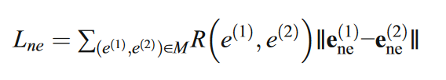

训练算法

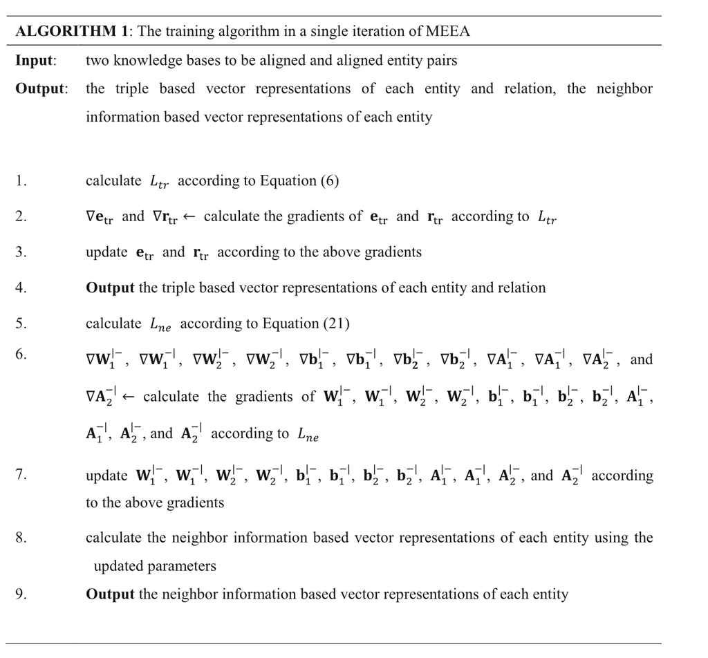

实体对齐

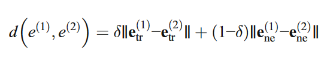

利用阈值$\theta_{tn}$来确定是否对齐

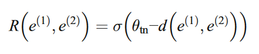

## Embedding-Based Entity Alignment Using Relation Structural Similarity

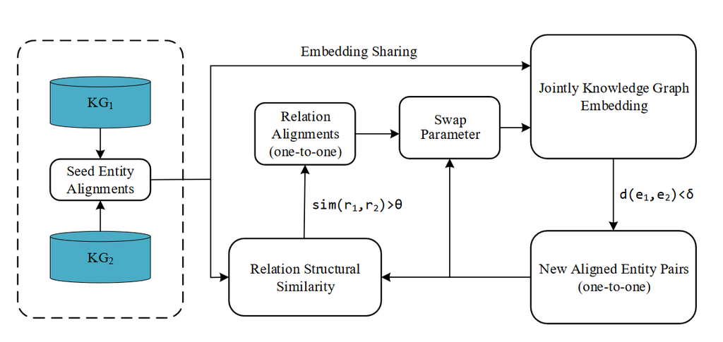

关系相似度：

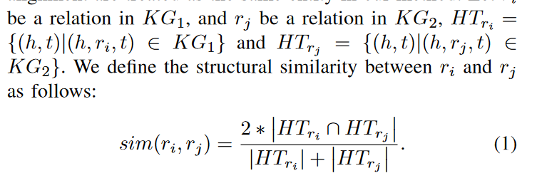

实体相似度直接使用曼哈顿距离

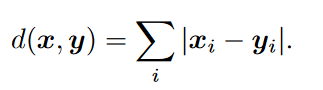

参数交换：即交换已经对齐的实体，形成新的三元组，增加训练数据

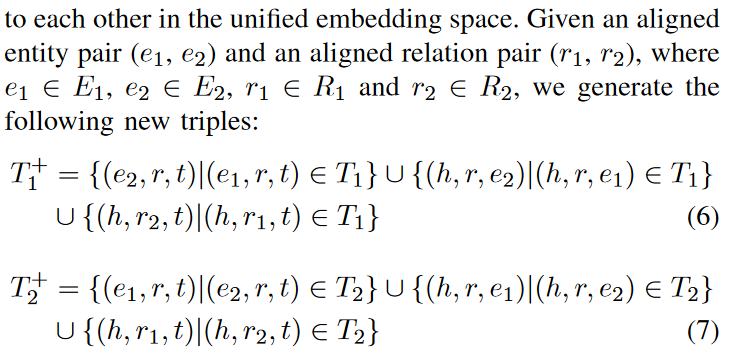

采用自对抗负采样

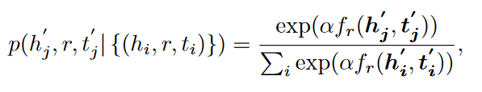

，先均匀负采样，然后计算每一个负样本的权重，

使用优化TransE进行训练，优化损失函数：

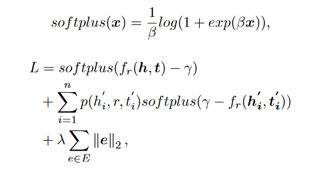

，Adam优化器

训练：

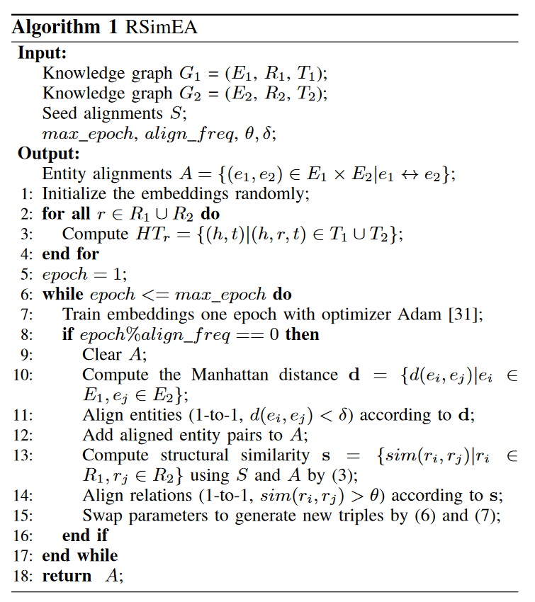

- 利用关系相似度确定对齐的关系
- 利用已经对齐的实体和关系(包括利用关系分数对齐的)生成新的三元组，此时两个知识图谱合并成了一个
- 利用新的知识图谱学习嵌入
- 对于负采样给一个权重
- 新的损失函数

## Neighborhood Matching Network for Entity Alignment

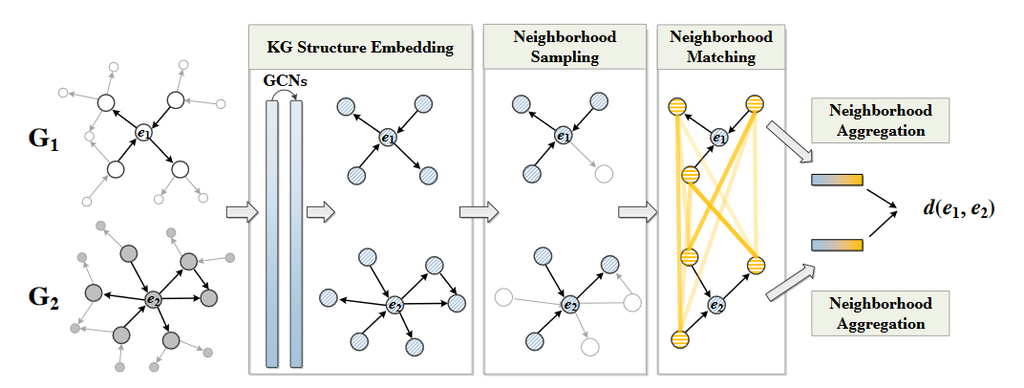

结构嵌入：将两个KG合并成一个，输入

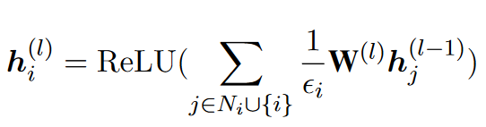

$\varepsilon$是归一化常量，$N_i$是$i$的邻居

利用高速门控网络控制噪声传播

邻居采样：并不是所有的一跳邻居都对对齐有利，所以进行一个下采样

给定一个实体$e_i$，采样1跳邻居$e_{i\_j}$的概率是

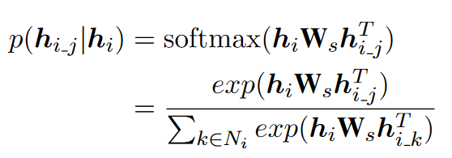

，$W_s$是共享权重矩阵。GCN学习的实体信息包含丰富的上下文信息，包括邻居信息和实体语义信息。某个邻居在上下文上越多的关联中心实体$e_i$，就更有可能被采样。对等实体在现实世界中也可能有相似上下文，所以邻居和中心实体越有关联，就能为对齐提供越多线索。

邻居匹配：对于实体$e_i$，需要比较取样后的邻居子图，选择最优的对齐实体。

由于子图数量巨大，全部进行匹配计算量过大，所以进行采样，计算两个实体之间的相似度进行匹配

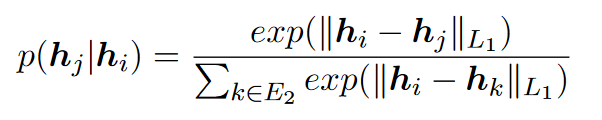

实体$i$的邻居$p$的跨图匹配向量为

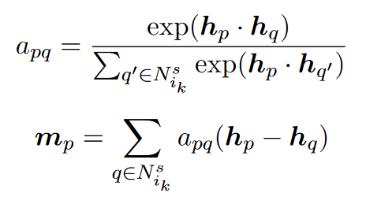

，$m_p$衡量了另一个子图中最近邻居和当前实体的距离，然后拼接邻居和带有权重的匹配向量

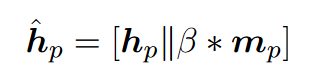

这种注意力机制能够精确检测另一子图的哪一个邻居最能匹配目标邻居

邻居合并：结合邻居连接信息生成用于对齐的最终嵌入。对于实体$e_i$，首先合并取样后的邻居$\{\hat h_p\}$，然后计算邻居表示

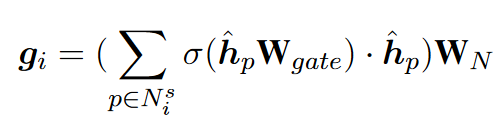

然后结合$h_i$和$g_i$表示实体

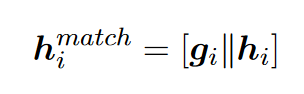

利用两个实体的距离判断是否应该对齐

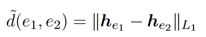

损失函数

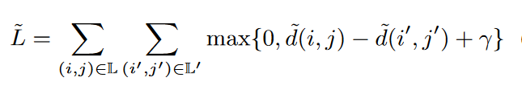

预训练之后，将损失函数替换成

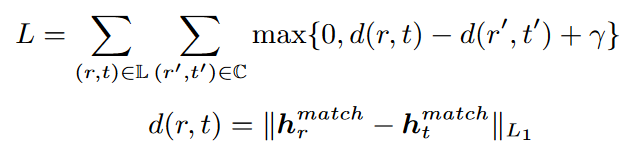

取样是不可微分的，因此不是直接采样，而是通过直观加权求和聚合所有信息

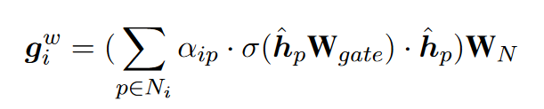

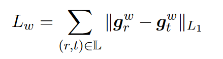

采样方式相对简单

- 利用邻居信息反映实体信息
- 候选实体对相互给出邻居注意力
- 对邻居进行采样减少计算量

## Dual Gated Graph Attention Networks with Dynamic Iterative Training for Cross-Lingual Entity Alignment